# Aula 8 - Econometria de Séries Temporais

Autor

João Ricardo F. de Lima

Data de Publicação

5 de maio de 2025

# MODELO SARIMA

Séries econômicas com periodicidade inferior a um ano, mensais ou trimestrais, por exemplo, normalmente exibem autocorrelação importante entre as observações dos instantes do tempo distantes entre si por *s* ou múltiplos de **s**, em que o **s** é o número de períodos contidos em um ano (**s**=12 para dados mensais e igual a 4 para dados trimestrais);

Esta correlação é devido à sazonalidade que é comum em séries de preços;

A correlação sazonal precisa ser modelada e por isto surgem os modelos **ARIMA sazonais** denominados de modelos **SARIMA**.

Os modelos SARIMA incorporam, alem dos componentes AR(p), MA(q) e d diferenciações consecutivas, os componentes autoregressivo sazonal, SAR(P), média móvel sazonal, SMA(Q), e D diferenciações sazonais necessárias caso a série apresente raiz unitária sazonal;

Assim, tem-se a denominação $SARIMA(p,d,q)x(P,D,Q)_s$;

A diferenciação sazonal é dada por

$$\Delta_{12}Y_t=Y_t-Y_{t-12}=(1-L^{12})Y_t$$

em que $\Delta_{12}=(1-L^{12})$ é chamado de *operador de diferença sazonal*

No R a série com uma diferença sazonal de 12 meses é gerada com `ds12x <- diff(x, lag=12)` na qual x é a série a ser diferenciada sazonalmente.

No Python a série com uma diferença sazonal de 12 meses é gerada com `ds12x <- x.diff(12)` na qual x é a série a ser diferenciada sazonalmente.

No caso de modelos estacionários puramente sazonais que apresentam componentes sazonais autorregressivos (SAR) e de média móvel (SMA), tem-se a seguinte estrutura:

$$y_t=A_1y_{t-s}+\dots+A_Py_{t-Ps}+u_t+M_1u_{t-s}+\dots+M_Qu_{t-Qs}$$

$$y_t-A_1y_{t-s}-\dots-A_Py_{t-Ps}=u_t+M_1u_{t-s}+\dots+M_Qu_{t-Qs}$$

$$(1-A_1L^s-\dots-A_PL^{Ps})yt=(1+M_1L^S+\dots+M_QL^{Qs})u_t$$

Caso a série não seja estacionária, precisando ser diferenciada sazonalmente, o modelo sazonal autorregressivo integrado de médias móveis é dado por:

$$y_t-y_{t-s}=A_1y_{t-s}+\dots+A_Py_{t-Ps}+u_t+M_1u_{t-s}+\dots+M_Qu_{t-Qs}-y_{t-s}$$

$$\Delta_s^Dy_t=y_{t-s}(A-1)+\dots+A_Py_{t-Ps}+u_t+M_1u_{t-s}+\dots+M_Qu_{t-Qs}$$

$$(1-A_1L^s-\dots-A_PL^{Ps})\Delta_s^Dy_t=(1-M_1L^S-\dots-M_QL^{Qs})u_t$$

que pode ser escrito de forma compacta como:

$$A(L^s)\Delta_s^Dy_t=M(L^s)u_t$$

E o modelo SARIMA geral $(p,d,q)x(P,D,Q)_s$ pode ser dado por

$$\alpha(L)A(L^s)\Delta_s^D\Delta^dy_t=m(L)M(L^s)u_t$$

# Entrada de dados no R

```r
#Direcionado o R para o Diretorio a ser trabalhado
#setwd('c:/Users/Joao Ricardo Lima/Dropbox/tempecon/dados_manga')
setwd('/Users/jricardofl/Dropbox/tempecon/dados_manga')

#Inicio do Script
#Pacotes a serem utilizados
library(mFilter)
library(forecast)
library(tibble)
library(dplyr)
library(tsutils)
library(ggthemes)
library(FinTS)
library(scales)
library(ggplot2)
library(uroot)
library(urca)
library(tseries)
library(lmtest)
library(magrittr)
library(lubridate)

options(digits=4)


#  Importação dos dados
dados <- read.csv2("dados_manga_palmer_semana.csv", dec = ",")
igpdi <- read.csv2("igpdi.csv", dec = ",")

# Limpeza e seleção de colunas
colnames(dados)[1] <- "produto"
dados_comb <- cbind(dados, igpdi)
dadosp <- dados_comb[, c("ano", "semana", "preco", "igpdi")]
dadosp$preco <- as.numeric(dadosp$preco)
dadosp$igpdi <- as.numeric(dadosp$igpdi)

#  Deflacionamento do preço
ultimo_igpdi <- as.numeric(tail(dadosp$igpdi, 1))
dadosp$preco_def <- dadosp$preco * (ultimo_igpdi / dadosp$igpdi)

#  Criando vetor de datas semanais
date <- seq(as.Date("2012-01-07"), to = as.Date("2025-05-02"), by = "1 week")
date <- date[date != as.Date("2016-12-31")]
date[date == as.Date("2022-12-31")] <- as.Date("2023-01-01")
date <- date[date != as.Date("2023-12-30")]
date <- c(date, as.Date("2025-05-02"))
dadosp$date <- date

#  Criando série temporal
preco_palmer <- ts(dadosp$preco_def, start = c(2012, 1), frequency = 52)
```

## Gráficos

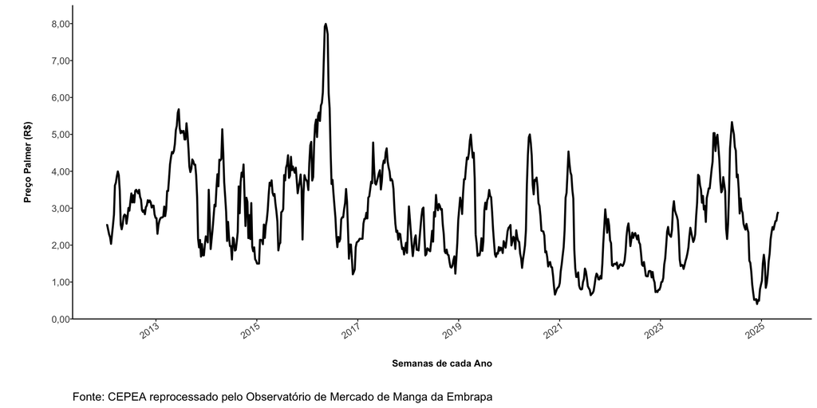

```r
#  Gráfico com ggplot2
g1 <- ggplot(dadosp, aes(x = date, y = preco_def)) +
  geom_line(lwd = 1) +
  labs(
    y = "Preço Palmer (R$)",
    x = "Semanas de cada Ano",
    caption = "Fonte: CEPEA reprocessado pelo Observatório de Mercado de Manga da Embrapa"
  ) +
  scale_y_continuous(
    limits = c(0, 8),
    n.breaks = 9,
    expand = expansion(add = c(0, 0.5)),
    labels = number_format(accuracy = 0.01, decimal.mark = ",")
  ) +
  scale_x_date(date_breaks = "2 years", labels = date_format("%Y")) +
  theme_classic() +
  theme(
    axis.text.x = element_text(angle = 35, hjust = 1, size = 10, margin = margin(b = 20)),
    axis.text.y = element_text(size = 10, margin = margin(l = 20)),
    axis.title.x = element_text(size = 10, face = "bold", margin = margin(b = 20)),
    axis.title.y = element_text(size = 10, face = "bold", margin = margin(l = 20)),
    plot.title = element_text(hjust = 0.5, size = 16, face = "italic"),
    plot.caption = element_text(hjust = 0, size = 12)
  )

g1
```

O Comando `monthplot` do R ajuda a entender a sazonalidade da série temporal. As linhas horizontais são os preços médios de cada semana e as linhas verticais são as variações de cada semana em relação à média geral.

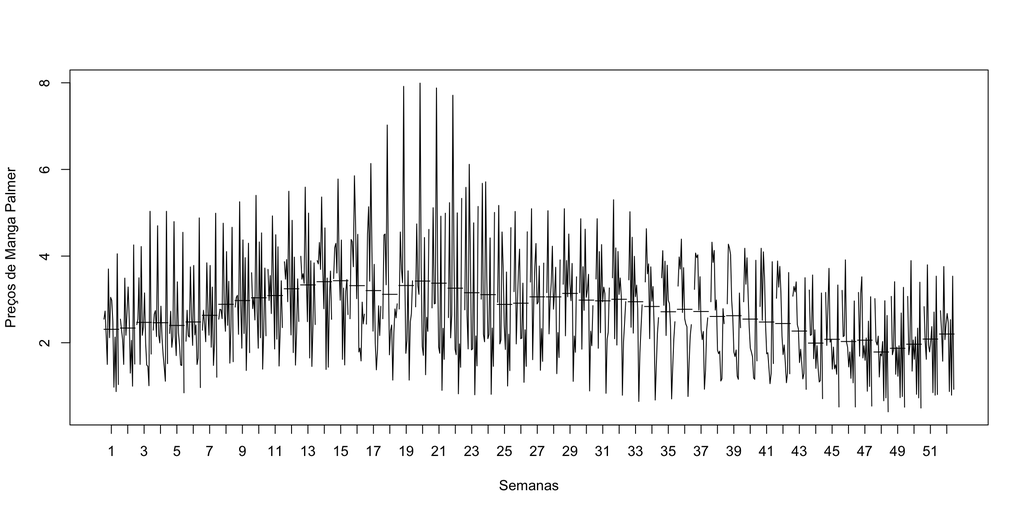

```r
monthplot(preco_palmer, ylab="Preços de Manga Palmer", xlab="Semanas")
```

## Decomposição da série

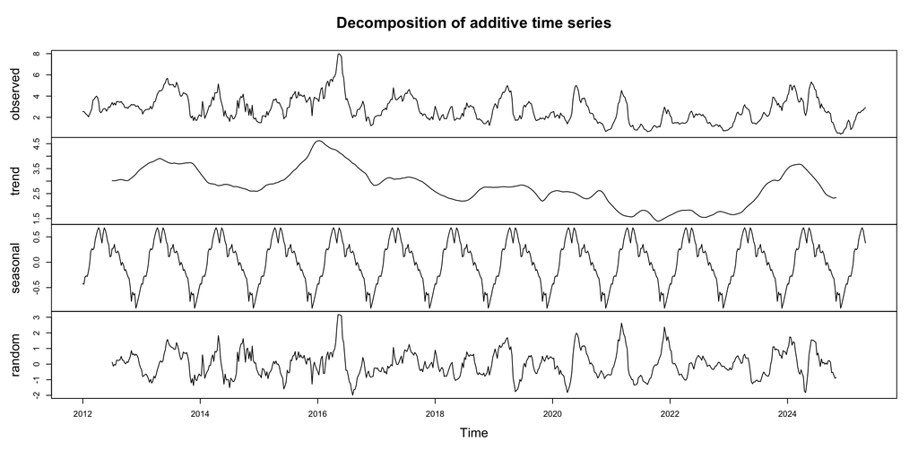

```r
plot(decompose(preco_palmer))
```

## Análise de Estacionariedade da série

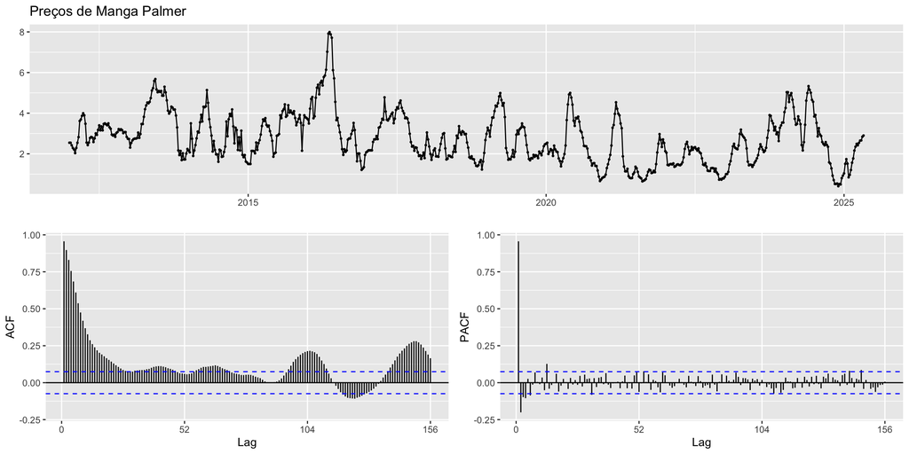

```r
#Estacionariedade da Serie
ggtsdisplay(preco_palmer, main='Preços de Manga Palmer')
```

```r
#Estatistica de Teste DFGLS para RPD
print(12*(length(preco_palmer)/100)^(1/4))
```

```
[1] 19.48
```

```r
precoC.dfgls <- ur.ers(preco_palmer, type = c("DF-GLS"),
                     model = c("constant"),
                     lag.max = 12)
summary(precoC.dfgls)
```

```
###############################################
# Elliot, Rothenberg and Stock Unit Root Test #
###############################################

Test of type DF-GLS
detrending of series with intercept


Call:
lm(formula = dfgls.form, data = data.dfgls)

Residuals:
    Min      1Q  Median      3Q     Max
-1.3922 -0.1828  0.0085  0.1919  1.4215

Coefficients:
              Estimate Std. Error t value Pr(>|t|)
yd.lag         -0.0547     0.0132   -4.15  3.8e-05 ***
yd.diff.lag1    0.1849     0.0382    4.84  1.6e-06 ***
yd.diff.lag2    0.0673     0.0389    1.73  0.08411 .
yd.diff.lag3    0.0878     0.0388    2.26  0.02397 *
yd.diff.lag4   -0.0376     0.0388   -0.97  0.33331
yd.diff.lag5    0.0726     0.0388    1.87  0.06167 .
yd.diff.lag6    0.0111     0.0386    0.29  0.77472
yd.diff.lag7   -0.0594     0.0386   -1.54  0.12389
yd.diff.lag8   -0.0196     0.0386   -0.51  0.61277
yd.diff.lag9    0.0179     0.0385    0.47  0.64119
yd.diff.lag10  -0.0405     0.0385   -1.05  0.29265
yd.diff.lag11   0.0666     0.0385    1.73  0.08419 .
yd.diff.lag12  -0.1287     0.0383   -3.36  0.00082 ***
---
Signif. codes:  0 '***' 0.001 '**' 0.01 '*' 0.05 '.' 0.1 ' ' 1

Residual standard error: 0.349 on 668 degrees of freedom
Multiple R-squared:  0.109, Adjusted R-squared:  0.0915
F-statistic: 6.27 on 13 and 668 DF,  p-value: 3.13e-11


Value of test-statistic is: -4.145

Critical values of DF-GLS are:
                 1pct  5pct 10pct
critical values -2.57 -1.94 -1.62
```

# Teste de Raiz Unitária Sazonal

Em um grande número de séries temporais econômicas mensais e trimestrais, o componente sazonal está presente, fazendo com que a série apresente picos ou vales em períodos de tempo determinados.

Quando existem indícios de sazonalidade estocástica, utilizam-se testes de raízes unitárias sazonais. A partir de tais testes, é possível analisar a estacionariedade de uma série temporal na presença de componentes sazonais e, conseqüentemente, definir a ordem de integração da mesma.

O teste mais conhecido de raízes sazonais foi o previsto por Hyllerberg et al (1990), chamado de teste HEGY.

No caso de séries trimestrais, para checar se existe raiz unitária sazonal é estimado o modelo:

$$\Delta_4y_t=\pi_1z_{1,t-1}+\pi_2z_{2,t-1}+\pi_3z_{3,t-1}+\pi_4z_{3,t-2}+\sum_{j=1}^{p}\alpha_j^*\Delta_4y_{t-j}+u_t$$

em que $z_{1t}=(1+L+L^2+L^3)y_t$, $z_{2t}=-(1-L+L^2+L^3)y_t$ e $z_{3t}=-(1-L^2)y_t$ com L sendo o operado de defasagem.

A hipótese nula de que $H_0:\pi_1=0$, $H_0:\pi_2=0$ e $H_0:\pi_3=\pi_4=0$, corresponde aos testes de raizes regulares, semestrais e anuais, respectivamente.

O modelo acima é estimado por MQO e se faz testes t para significâncias individuais e F para testar hipóteses conjuntas.

No caso de séries mensais, para checar se existe raiz unitária sazonal é estimado o modelo:

$$\begin{align*}
\Delta_{12}y_t=\pi_1z_{1,t-1}+\pi_2z_{2,t-1}+\pi_3z_{3,t-1}+\pi_4z_{3,t-2}+\pi_5z_{4,t-1}+ \\ \pi_6z_{4,t-2}+\pi_7z_{5,t-1}+\pi_8z_{5,t-2}+\pi_9z_{6,t-1}+\pi_{10}z_{6,t-2}+ \\
\pi_{11}z_{7,t-1}+\pi_{12}z_{7,t-2}+\sum_{j=1}^{p}\alpha_j^*\Delta_{12}y_{t-j}+u_t
\end{align*}$$

O processo tem uma raiz unitaria regular se $\pi=0$ e tem raiz unitária sazonal se qualquer outro $\pi_i$ (i=2,…,12) for zero;

No caso de raízes mensais, as significâncias das frequências indicam o ciclo sazonal.

| **Freq.** | **$0$** | **$\pi$** | **$\frac{\pi}{2}$** | **$\frac{2\pi}{3}$** | **$\frac{\pi}{3}$** | **$\frac{5\pi}{6}$** | **$\frac{\pi}{6}$** |
| --- | --- | --- | --- | --- | --- | --- | --- |
| Coef | $\pi_1$ | $\pi_2$ | $\pi_3$ $\pi_4$ | $\pi_5$ $\pi_6$ | $\pi_7$ $\pi_8$ | $\pi_9$ $\pi_{10}$ | $\pi_{11}$ $\pi_{12}$ |
| Período | $\infty$ | 2 | 4 | 3 | 6 | 2.4 | 12 |
| Ciclo | $0$ | 6 | 3 | 4 | 2 | 5 | 1 |

Assim a frequência zero corresponde a zero ciclos sazonais, ou seja, uma raiz unitária regular. Na frequência $\pi$ se tem 6 ciclos sazonais de 2 períodos (meses) e assim sucessivamente, até a frequência $\pi/6$ que corresponde a um ciclo sazonal de 12 meses.

## Exemplo para uma série mensal

```r
data("AirPassengers")

#Teste de Raiz Unitária Sazonal HEGY
hegy.test(log(AirPassengers), deterministic = c(1,1,1),
          lag.method = "AICc")
```

```
    HEGY test for unit roots

data:  log(AirPassengers)

        statistic p-value
t_1         -1.25    0.88
t_2         -3.19    0.02 *
F_3:4        6.79    0.07 .
F_5:6        8.81    0.02 *
F_7:8       16.42       0 ***
F_9:10       4.07    0.32
F_11:12      8.29    0.03 *
F_2:12      22.56    0.02 *
F_1:12       20.7       0 ***
---
Signif. codes: 0 '***' 0.001 '**' 0.01 '*' 0.05 '.' 0.1 ' ' 1

Deterministic terms: constant + trend + seasonal dummies
Lag selection criterion and order: AIC, 0
P-values: based on response surface regressions
```

### Resultado do Teste HEGY – `log(AirPassengers)`

O teste HEGY foi aplicado à série `log(AirPassengers)`, com termos determinísticos de constante, tendência e dummies sazonais, e seleção automática de defasagens pelo critério AICc. Os resultados são apresentados abaixo:

| Estatística | Valor | p-valor | Interpretação |
| --- | --- | --- | --- |
| `t_1` | -1,2494 | 0,8795 | Não rejeita raiz unitária não-sazonal (nível) |
| `t_2` | -3,1872 | 0,0231 * | Rejeita raiz unitária sazonal com frequência semestral |
| `F_3:4` | 6,7922 | 0,0721 . | Rejeita raiz unitária sazonal com frequência trimestral |
| `F_5:6` | 8,8093 | 0,0208 * | Rejeita raiz unitária sazonal com frequência quadrimestral |
| `F_7:8` | 16,4172 | 0,0001 *** | Rejeição (sazonalidade bimestral não estacionária) |
| `F_9:10` | 4,0688 | 0,3152 | Não rejeita (não estacionariedade pode estar presente) |
| `F_11:12` | 8,2888 | 0,0291 * | Rejeita sazonalidade mensal como raiz unitária - mensal |
| `F_2:12` | 22,5616 | 0,0195 * | Rejeita conjunto de raízes unitárias sazonais (2–12) |
| `F_1:12` | 20,6974 | 0,0002 *** | Rejeita presença de qualquer raiz unitária |

A série `log(AirPassengers)` apresenta evidências de **raízes unitárias sazonais e não-sazonais**, indicando a necessidade de aplicar **diferença regular (d = 1) e sazonal (D = 1)**.

No caso dos preços de manga, contudo, a frequência é semanal.

```r
frequency(preco_palmer)
```

```
[1] 52
```

Assim, uma possibilidade é trabalhar com os termos de Fourier. Os termos de Fourier são funções seno ($\sin$) e cosseno ($\cos$) que capturam padrões periódicos na sua série temporal.

Eles vêm da ideia de que qualquer padrão periódico (como a sazonalidade) pode ser decomposto como uma combinação de ondas senoidais e cossenoidais.

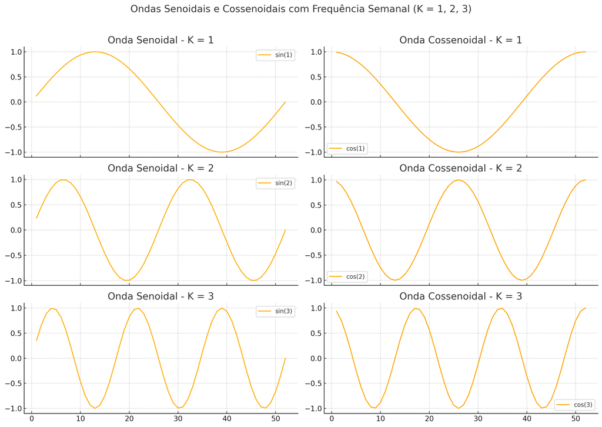

## Estimação dos Modelos

O modelo abaixo estimado é um ARIMAX, um ARIMA com variáveis exógenas, que são os termos de Fourier para explicar a sazonalidade. Neste caso, foi usado o $K = 1$, ou seja, uma oscilação completa por ano (padrão mais amplo).

```r
# Passo 1: Criar os termos de Fourier com K = 1
K <- 1
xreg_fourier <- fourier(preco_palmer, K = K)

# Passo 2: Ajustar o modelo ARIMA com os termos de Fourier como regressores
modelo_fourier_k1 <- auto.arima(preco_palmer, xreg = xreg_fourier, seasonal = FALSE)

# Passo 3: Ver o resumo do modelo
summary(modelo_fourier_k1)
```

```
Series: preco_palmer
Regression with ARIMA(3,1,1) errors

Coefficients:
         ar1    ar2    ar3    ma1  S1-52   C1-52
      -0.785  0.183  0.089  0.948  0.349  -0.491
s.e.   0.045  0.048  0.038  0.025  0.202   0.200

sigma^2 = 0.126:  log likelihood = -261.8
AIC=537.5   AICc=537.7   BIC=569.3

Training set error measures:
                     ME   RMSE    MAE     MPE  MAPE   MASE       ACF1
Training set -0.0006968 0.3527 0.2502 -0.7046 10.16 0.1849 -0.0006747
```

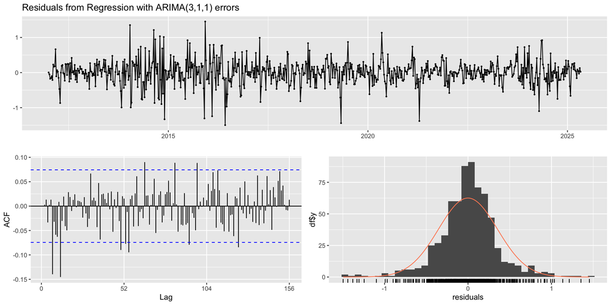

```
    Ljung-Box test

data:  Residuals from Regression with ARIMA(3,1,1) errors
Q* = 133, df = 100, p-value = 0.01

Model df: 4.   Total lags used: 104
```

```r
# Passo 4: Diagnóstico dos resíduos
checkresiduals(modelo_fourier_k1)
```

Abaixo é estimado um modelo SARIMA tradicional para comparação.

```r
# Estimar modelo SARIMA com diferenciação sazonal
modelo_sarima <- auto.arima(preco_palmer, seasonal = TRUE)

# Ver o resumo
summary(modelo_sarima)
```

```
Series: preco_palmer
ARIMA(3,1,1)

Coefficients:
         ar1    ar2    ar3    ma1
      -0.770  0.208  0.103  0.947
s.e.   0.045  0.047  0.038  0.026

sigma^2 = 0.127:  log likelihood = -266.1
AIC=542.3   AICc=542.4   BIC=565

Training set error measures:
                    ME   RMSE    MAE    MPE  MAPE   MASE      ACF1
Training set 0.0004386 0.3549 0.2534 -0.628 10.29 0.1873 -0.001857
```

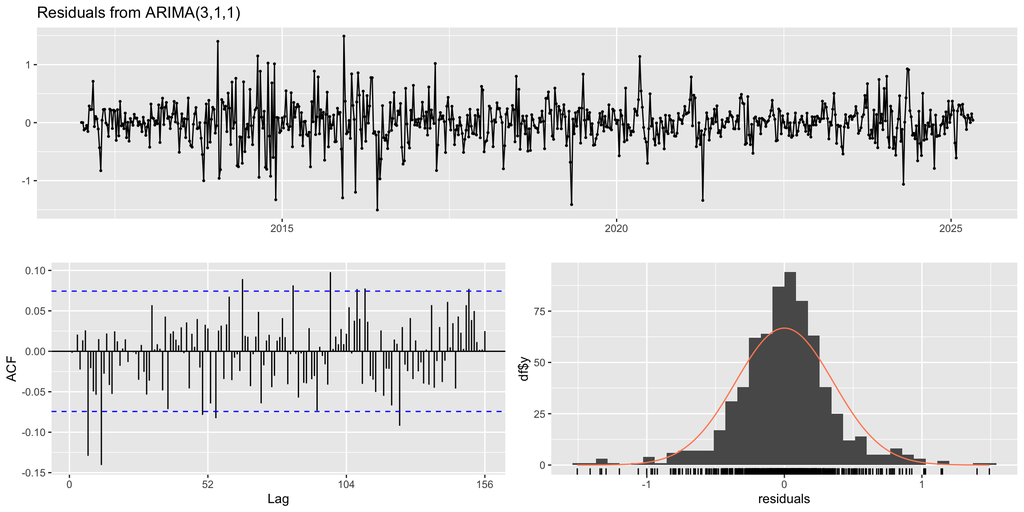

```
    Ljung-Box test

data:  Residuals from ARIMA(3,1,1)
Q* = 126, df = 100, p-value = 0.04

Model df: 4.   Total lags used: 104
```

```r
# Diagnóstico de resíduos
checkresiduals(modelo_sarima)
```

## Previsão 16 semanas a frente

```r
# Sabendo que preco_palmer é uma  ts
n_total <- length(preco_palmer)
n_test <- 16

# Separar treino e teste
y_train <- head(preco_palmer, n_total - n_test)
y_test <- tail(preco_palmer, n_test)

# Criar Fourier com K = 1 e frequência 52
K <- 1
m <- 52
xreg_train <- fourier(ts(y_train, frequency = m), K = K)
xreg_test  <- fourier(ts(preco_palmer, frequency = m), K = K, h = n_test)

#Estimação do modelo
modelo_fourier <- Arima(
  y = y_train,
  order = c(3, 1, 1),
  seasonal = list(order = c(0, 0, 0), period = NA),
  xreg = xreg_train
)

summary(modelo_fourier)
```

```
Series: y_train
Regression with ARIMA(3,1,1) errors

Coefficients:
         ar1    ar2    ar3    ma1  S1-52   C1-52
      -0.785  0.184  0.095  0.945  0.357  -0.476
s.e.   0.047  0.048  0.039  0.027  0.205   0.205

sigma^2 = 0.127:  log likelihood = -260.1
AIC=534.2   AICc=534.4   BIC=565.8

Training set error measures:
                    ME  RMSE   MAE     MPE  MAPE   MASE      ACF1
Training set -0.001142 0.355 0.252 -0.6964 10.09 0.1886 -0.001132
```

```r
#Previsao
forecast_result <- forecast(modelo_fourier, xreg = xreg_test, h = n_test)
```

```r
# Criar vetor de datas da série original
datas <- time(preco_palmer)

# Construir dataframe completo com treino, teste e previsão
dados_plot <- data.frame(
  data = datas,
  preco = as.numeric(preco_palmer),
  tipo = c(rep("Treino", length(y_train)), rep("Teste", length(y_test)))
)

# Adicionar coluna com previsões
dados_plot$previsao <- NA
dados_plot$previsao[(n_total - n_test + 1):n_total] <- as.numeric(forecast_result$mean)

tail(dados_plot, 16)
```

|  | data | preco | tipo | previsao |
| --- | --- | --- | --- | --- |
| 679 | 2025 | 1.7386 | Teste | 2.471 |
| 680 | 2025 | 1.5175 | Teste | 2.561 |
| 681 | 2025 | 0.8442 | Teste | 2.540 |
| 682 | 2025 | 0.9652 | Teste | 2.566 |
| 683 | 2025 | 1.2040 | Teste | 2.528 |
| 684 | 2025 | 1.5622 | Teste | 2.525 |
| 685 | 2025 | 1.7711 | Teste | 2.475 |
| 686 | 2025 | 2.1600 | Teste | 2.451 |
| 687 | 2025 | 2.3500 | Teste | 2.391 |
| 688 | 2025 | 2.4900 | Teste | 2.350 |

[output cut: 6 more lines]

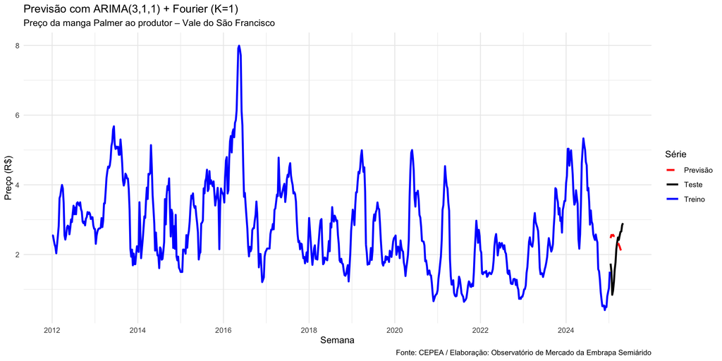

```r
# Plotar com ggplot2
ggplot(dados_plot, aes(x = data)) +
  geom_line(aes(y = preco, color = tipo), size = 1.1) +
  geom_line(aes(y = previsao, color = "Previsão"), linetype = "dashed", size = 1.1) +
  scale_color_manual(
    values = c("Treino" = "blue", "Teste" = "black", "Previsão" = "red")
  ) +
  labs(
    title = "Previsão com ARIMA(3,1,1) + Fourier (K=1)",
    subtitle = "Preço da manga Palmer ao produtor – Vale do São Francisco",
    x = "Semana",
    y = "Preço (R$)",
    color = "Série",
    caption = "Fonte: CEPEA / Elaboração: Observatório de Mercado da Embrapa Semiárido"
  ) +
  scale_x_continuous(breaks = seq(2012, 2026, by = 2)) +
  theme_minimal()
```

# Entrada de dados no Python

```python
# Bibliotecas
import pandas as pd
import plotnine as p9
from pathlib import Path
from statsmodels.tsa.seasonal import seasonal_decompose
import matplotlib.pyplot as plt
from statsmodels.graphics.tsaplots import plot_acf, plot_pacf
from arch.unitroot import DFGLS
from pmdarima import auto_arima
from pmdarima.preprocessing import FourierFeaturizer
from pmdarima.arima import ARIMA

# Caminho para os arquivos
data_dir = Path("/Users/jricardofl/Dropbox/tempecon/dados_manga")

# Load mango price dataset and drop specified columns
df = (
    pd.read_csv(data_dir/'dados_manga_palmer_semana.csv', sep=';', decimal='.')
    .drop(columns=['produto', 'regiao', 'ano', 'semana'])
)

# Create the date range from 2012-01-07 to today
date_range = pd.date_range(start='2012-01-01', end=pd.Timestamp.today(), freq='W-SAT')

# Remove the specific dates (53rd weeks)
dates_to_remove = [pd.Timestamp('2016-12-31'), pd.Timestamp('2022-12-31')]
date_range = date_range[~date_range.isin(dates_to_remove)]
date_range = date_range[:len(df)]

# Assign the date range as a new column
df['date'] = date_range
# Assign the date range as a new column
df['date2'] = date_range[:len(df)]

# Set the date as the index
df = df.set_index('date')

# Load igpdi dataset
igpdi = (
    pd.read_csv(data_dir/'igpdi.csv', sep=';', decimal='.')
    .assign(date=df.index)
    .drop(columns=['ano', 'semana'])
    .set_index('date')
)

# Merge DataFrames
tabela = df.join(igpdi, how='inner')

# Display the merged DataFrame
#print(tabela)

# Deflacionar a série com data base = último mês observado
indice_data_base = tabela.query("date == date.max()").igpdi.values[0]
tabela = tabela.assign(real = lambda x: (indice_data_base / x.igpdi) * x.preco)

# Criação da variável preco_palmer
preco_palmer = tabela['real']
```

## Gráfico

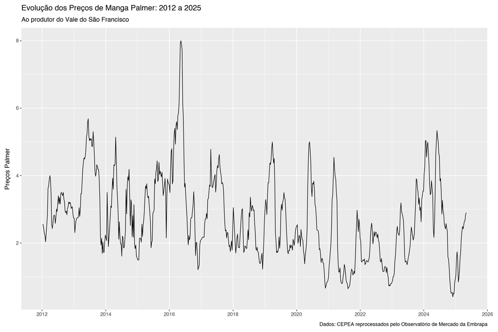

```python
# Visualização de dados
plot = (
  p9.ggplot(tabela) +
  p9.aes(x = "date2", y = "real") +
  p9.geom_line() +
  p9.scale_x_date(date_breaks = "2 year", date_labels = "%Y") +
  p9.labs(
    title = "Evolução dos Preços de Manga Palmer: 2012 a 2025",
    subtitle = "Ao produtor do Vale do São Francisco",
    x = "",
    y = "Preços Palmer",
    caption = "Dados: CEPEA reprocessados pelo Observatório de Mercado da Embrapa"
    )+
    p9.theme(
        figure_size=(12, 8)
        )
)

plot.show()
```

## Decomposição da série

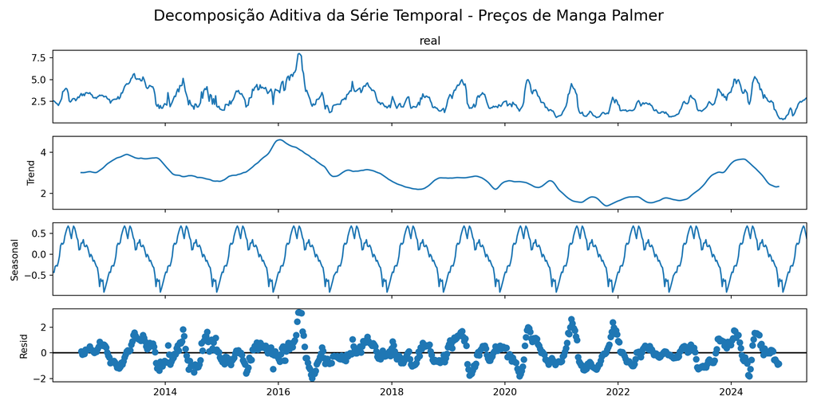

```python
# Decompose the series (additive model)
decompa = seasonal_decompose(preco_palmer, model='additive', period=52)  # Weekly data has a period of 52

# Plot the decomposition
decompa.plot()
plt.suptitle("Decomposição Aditiva da Série Temporal - Preços de Manga Palmer", fontsize=16)
plt.tight_layout()
plt.show()
```

## Análise de Estacionariedade da série

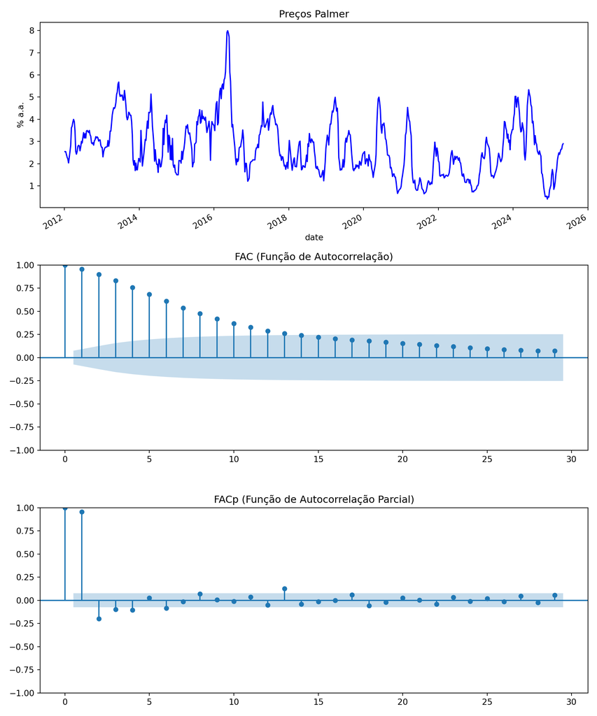

```python
# Plota IPCA, FAC, e FACpa
fig, axes = plt.subplots(3, 1, figsize=(10, 12))

# Plota IPCA
tabela['real'].plot(ax=axes[0], title='Preços Palmer', color='blue')
axes[0].set_ylabel('% a.a.')

# Plota FAC
plot_acf(tabela['real'], ax=axes[1], title='FAC (Função de Autocorrelação)')

# Plota FACp
plot_pacf(tabela['real'], ax=axes[2], title='FACp (Função de Autocorrelação Parcial)', method='ywm')

plt.tight_layout()
plt.show()
```

```python
# Executa o teste DF-GLS com seleção automática de defasagens
dfgls_preco = DFGLS(preco_palmer, lags=None, trend='c')  # 'ct' para constante + tendência. Apenas c = constante.

# Exibe os resultados
print(dfgls_preco.summary())
```

```
      Dickey-Fuller GLS Results
=====================================
Test Statistic                 -4.145
P-value                         0.000
Lags                               12
-------------------------------------

Trend: Constant
Critical Values: -2.60 (1%), -1.97 (5%), -1.65 (10%)
Null Hypothesis: The process contains a unit root.
Alternative Hypothesis: The process is weakly stationary.
```

## Estimação dos Modelos

```python
# Criar índice de datas (já usado no seu dataframe 'tabela')
y = tabela['real'].values
index = tabela.index

modelo_arima = auto_arima(
    y,
    seasonal=False,  # importante!
    stepwise=True,
    suppress_warnings=True,
    information_criterion='aic',
    trace=True
)
```

```
Performing stepwise search to minimize aic
 ARIMA(2,1,2)(0,0,0)[0] intercept   : AIC=545.890, Time=9.67 sec
 ARIMA(0,1,0)(0,0,0)[0] intercept   : AIC=571.984, Time=0.33 sec
 ARIMA(1,1,0)(0,0,0)[0] intercept   : AIC=552.538, Time=0.41 sec
 ARIMA(0,1,1)(0,0,0)[0] intercept   : AIC=554.983, Time=0.69 sec
 ARIMA(0,1,0)(0,0,0)[0]             : AIC=569.986, Time=0.12 sec
 ARIMA(1,1,2)(0,0,0)[0] intercept   : AIC=552.832, Time=2.53 sec
 ARIMA(2,1,1)(0,0,0)[0] intercept   : AIC=552.862, Time=4.10 sec
 ARIMA(3,1,2)(0,0,0)[0] intercept   : AIC=546.077, Time=4.26 sec
 ARIMA(2,1,3)(0,0,0)[0] intercept   : AIC=545.839, Time=4.83 sec
 ARIMA(1,1,3)(0,0,0)[0] intercept   : AIC=544.868, Time=3.66 sec
 ARIMA(0,1,3)(0,0,0)[0] intercept   : AIC=549.474, Time=0.89 sec
 ARIMA(1,1,4)(0,0,0)[0] intercept   : AIC=531.071, Time=7.57 sec
 ARIMA(0,1,4)(0,0,0)[0] intercept   : AIC=550.085, Time=1.16 sec
 ARIMA(2,1,4)(0,0,0)[0] intercept   : AIC=inf, Time=11.71 sec
 ARIMA(1,1,5)(0,0,0)[0] intercept   : AIC=551.390, Time=8.08 sec
 ARIMA(0,1,5)(0,0,0)[0] intercept   : AIC=549.411, Time=1.05 sec
 ARIMA(2,1,5)(0,0,0)[0] intercept   : AIC=534.913, Time=8.37 sec
 ARIMA(1,1,4)(0,0,0)[0]             : AIC=inf, Time=4.57 sec

Best model:  ARIMA(1,1,4)(0,0,0)[0] intercept
Total fit time: 74.166 seconds
```

```python
print(modelo_arima.summary())
```

```
                               SARIMAX Results
==============================================================================
Dep. Variable:                      y   No. Observations:                  694
Model:               SARIMAX(1, 1, 4)   Log Likelihood                -258.536
Date:                Seg, 05 Mai 2025   AIC                            531.071
Time:                        08:15:18   BIC                            562.858
Sample:                             0   HQIC                           543.365
                                - 694
Covariance Type:                  opg
==============================================================================
                 coef    std err          z      P>|z|      [0.025      0.975]
------------------------------------------------------------------------------
intercept  -8.573e-05      0.000     -0.253      0.800      -0.001       0.001
ar.L1          0.8935      0.029     31.006      0.000       0.837       0.950
ma.L1         -0.7418      0.036    -20.395      0.000      -0.813      -0.671
ma.L2         -0.0917      0.035     -2.609      0.009      -0.161      -0.023
ma.L3         -0.0186      0.039     -0.478      0.632      -0.095       0.058
ma.L4         -0.1254      0.036     -3.451      0.001      -0.197      -0.054
sigma2         0.1224      0.005     27.178      0.000       0.114       0.131
===================================================================================
Ljung-Box (L1) (Q):                   0.27   Jarque-Bera (JB):               188.87
Prob(Q):                              0.61   Prob(JB):                         0.00
Heteroskedasticity (H):               0.43   Skew:                             0.01
Prob(H) (two-sided):                  0.00   Kurtosis:                         5.56
===================================================================================

Warnings:
[1] Covariance matrix calculated using the outer product of gradients (complex-step).
```

```python
# Ajustar modelo ARIMA(1,1,4) com termos de Fourier

# Criar os termos de Fourier com K = 1
fourier = FourierFeaturizer(m=52, k=1)
_, X_fourier = fourier.fit_transform(index)

modelo_fourier = ARIMA(order=(1, 1, 4), seasonal=False)
modelo_fourier.fit(y, X_fourier)
```

```
ARIMA(order=(1, 1, 4))
```

```python
# Mostrar resumo
print(modelo_fourier.summary())
```

```
                               SARIMAX Results
==============================================================================
Dep. Variable:                      y   No. Observations:                  694
Model:               SARIMAX(1, 1, 4)   Log Likelihood                -252.588
Date:                Seg, 05 Mai 2025   AIC                            523.176
Time:                        08:15:29   BIC                            564.045
Sample:                             0   HQIC                           538.982
                                - 694
Covariance Type:                  opg
=================================================================================
                    coef    std err          z      P>|z|      [0.025      0.975]
---------------------------------------------------------------------------------
intercept        -0.0001      0.000     -0.367      0.714      -0.001       0.001
FOURIER_S52-0     0.4005      0.188      2.129      0.033       0.032       0.769
FOURIER_C52-0    -0.4741      0.169     -2.807      0.005      -0.805      -0.143
ar.L1             0.8966      0.032     28.263      0.000       0.834       0.959
ma.L1            -0.7720      0.037    -20.643      0.000      -0.845      -0.699
ma.L2            -0.0969      0.036     -2.729      0.006      -0.166      -0.027
ma.L3             0.0138      0.040      0.341      0.733      -0.066       0.093
ma.L4            -0.1207      0.037     -3.274      0.001      -0.193      -0.048
sigma2            0.1213      0.004     27.230      0.000       0.113       0.130
===================================================================================
Ljung-Box (L1) (Q):                   0.05   Jarque-Bera (JB):               211.68
Prob(Q):                              0.81   Prob(JB):                         0.00
Heteroskedasticity (H):               0.44   Skew:                            -0.05
Prob(H) (two-sided):                  0.00   Kurtosis:                         5.71
===================================================================================

Warnings:
[1] Covariance matrix calculated using the outer product of gradients (complex-step).
```

```python
# Estimar modelo SARIMA com diferenciação sazonal (sazonalidade semanal: m = 52)
modelo_sarima = auto_arima(
    y,
    seasonal=True,
    m=52,  # periodicidade semanal (52 semanas por ano)
    stepwise=True,
    suppress_warnings=True,
    information_criterion='aic',
    trace=True
)
```

```
Performing stepwise search to minimize aic
 ARIMA(2,1,2)(1,0,1)[52] intercept   : AIC=inf, Time=74.48 sec
 ARIMA(0,1,0)(0,0,0)[52] intercept   : AIC=571.984, Time=0.33 sec
 ARIMA(1,1,0)(1,0,0)[52] intercept   : AIC=554.393, Time=22.91 sec
 ARIMA(0,1,1)(0,0,1)[52] intercept   : AIC=556.894, Time=10.69 sec
 ARIMA(0,1,0)(0,0,0)[52]             : AIC=569.986, Time=0.12 sec
 ARIMA(1,1,0)(0,0,0)[52] intercept   : AIC=552.538, Time=0.20 sec
 ARIMA(1,1,0)(0,0,1)[52] intercept   : AIC=554.399, Time=7.96 sec
 ARIMA(1,1,0)(1,0,1)[52] intercept   : AIC=inf, Time=59.18 sec
 ARIMA(2,1,0)(0,0,0)[52] intercept   : AIC=551.790, Time=0.36 sec
 ARIMA(2,1,0)(1,0,0)[52] intercept   : AIC=553.506, Time=7.85 sec
 ARIMA(2,1,0)(0,0,1)[52] intercept   : AIC=553.516, Time=5.67 sec
 ARIMA(2,1,0)(1,0,1)[52] intercept   : AIC=inf, Time=47.63 sec
 ARIMA(3,1,0)(0,0,0)[52] intercept   : AIC=551.016, Time=0.24 sec
 ARIMA(3,1,0)(1,0,0)[52] intercept   : AIC=552.601, Time=8.89 sec
 ARIMA(3,1,0)(0,0,1)[52] intercept   : AIC=552.612, Time=9.27 sec
 ARIMA(3,1,0)(1,0,1)[52] intercept   : AIC=inf, Time=40.99 sec
 ARIMA(4,1,0)(0,0,0)[52] intercept   : AIC=549.734, Time=0.65 sec
 ARIMA(4,1,0)(1,0,0)[52] intercept   : AIC=551.092, Time=13.80 sec
 ARIMA(4,1,0)(0,0,1)[52] intercept   : AIC=551.116, Time=13.91 sec
 ARIMA(4,1,0)(1,0,1)[52] intercept   : AIC=inf, Time=51.42 sec
 ARIMA(5,1,0)(0,0,0)[52] intercept   : AIC=550.477, Time=0.95 sec
 ARIMA(4,1,1)(0,0,0)[52] intercept   : AIC=550.766, Time=1.29 sec
 ARIMA(3,1,1)(0,0,0)[52] intercept   : AIC=544.262, Time=1.34 sec
 ARIMA(3,1,1)(1,0,0)[52] intercept   : AIC=545.694, Time=25.07 sec
 ARIMA(3,1,1)(0,0,1)[52] intercept   : AIC=545.717, Time=39.30 sec
 ARIMA(3,1,1)(1,0,1)[52] intercept   : AIC=inf, Time=46.12 sec
 ARIMA(2,1,1)(0,0,0)[52] intercept   : AIC=552.862, Time=0.75 sec
 ARIMA(3,1,2)(0,0,0)[52] intercept   : AIC=546.077, Time=1.21 sec
 ARIMA(2,1,2)(0,0,0)[52] intercept   : AIC=545.890, Time=1.06 sec
 ARIMA(4,1,2)(0,0,0)[52] intercept   : AIC=inf, Time=2.22 sec
 ARIMA(3,1,1)(0,0,0)[52]             : AIC=542.263, Time=0.45 sec
 ARIMA(3,1,1)(1,0,0)[52]             : AIC=543.695, Time=7.05 sec
 ARIMA(3,1,1)(0,0,1)[52]             : AIC=543.718, Time=8.64 sec
 ARIMA(3,1,1)(1,0,1)[52]             : AIC=inf, Time=22.20 sec
 ARIMA(2,1,1)(0,0,0)[52]             : AIC=550.863, Time=0.24 sec
 ARIMA(3,1,0)(0,0,0)[52]             : AIC=549.016, Time=0.13 sec
 ARIMA(4,1,1)(0,0,0)[52]             : AIC=548.767, Time=0.36 sec
 ARIMA(3,1,2)(0,0,0)[52]             : AIC=544.078, Time=0.60 sec
 ARIMA(2,1,0)(0,0,0)[52]             : AIC=549.790, Time=0.07 sec
 ARIMA(2,1,2)(0,0,0)[52]             : AIC=543.890, Time=0.61 sec
 ARIMA(4,1,0)(0,0,0)[52]             : AIC=547.735, Time=0.19 sec
 ARIMA(4,1,2)(0,0,0)[52]             : AIC=inf, Time=1.46 sec

Best model:  ARIMA(3,1,1)(0,0,0)[52]
Total fit time: 538.136 seconds
```

```python
# Mostrar o resumo
print(modelo_sarima.summary())
```

```
                               SARIMAX Results
==============================================================================
Dep. Variable:                      y   No. Observations:                  694
Model:               SARIMAX(3, 1, 1)   Log Likelihood                -266.131
Date:                Seg, 05 Mai 2025   AIC                            542.263
Time:                        08:24:29   BIC                            564.968
Sample:                             0   HQIC                           551.044
                                - 694
Covariance Type:                  opg
==============================================================================
                 coef    std err          z      P>|z|      [0.025      0.975]
------------------------------------------------------------------------------
ar.L1         -0.7702      0.041    -18.732      0.000      -0.851      -0.690
ar.L2          0.2078      0.039      5.355      0.000       0.132       0.284
ar.L3          0.1026      0.033      3.144      0.002       0.039       0.166
ma.L1          0.9467      0.035     27.364      0.000       0.879       1.015
sigma2         0.1262      0.005     27.472      0.000       0.117       0.135
===================================================================================
Ljung-Box (L1) (Q):                   0.00   Jarque-Bera (JB):               195.02
Prob(Q):                              0.96   Prob(JB):                         0.00
Heteroskedasticity (H):               0.45   Skew:                            -0.15
Prob(H) (two-sided):                  0.00   Kurtosis:                         5.58
===================================================================================

Warnings:
[1] Covariance matrix calculated using the outer product of gradients (complex-step).
```

# Previsão 16 semanas a frente

```python
from pmdarima.arima import ARIMA
from pmdarima.preprocessing import FourierFeaturizer

# Divide series
n_test = 16
y_train, y_test = y[:-n_test], y[-n_test:]
index_train, index_test = index[:-n_test], index[-n_test:]

# Fourier features
fourier = FourierFeaturizer(m=52, k=1)
_, X_full = fourier.fit_transform(index)
X_train = X_full[:-n_test].values.astype(float)
X_test = X_full[-n_test:].values.astype(float)


# Fit and predict
modelo_pmd = ARIMA(order=(1, 1, 4), seasonal=False).fit(y_train, X_train)
modelo_pmd.fit(y_train)
```

```
ARIMA(order=(1, 1, 4))
```

```python
# Mostrar resumo
print(modelo_pmd.summary())
```

```
                               SARIMAX Results
==============================================================================
Dep. Variable:                      y   No. Observations:                  678
Model:               SARIMAX(1, 1, 4)   Log Likelihood                -256.978
Date:                Seg, 05 Mai 2025   AIC                            527.957
Time:                        08:24:33   BIC                            559.580
Sample:                             0   HQIC                           540.200
                                - 678
Covariance Type:                  opg
==============================================================================
                 coef    std err          z      P>|z|      [0.025      0.975]
------------------------------------------------------------------------------
intercept     -0.0002      0.000     -0.501      0.616      -0.001       0.000
ar.L1          0.8993      0.028     31.935      0.000       0.844       0.955
ma.L1         -0.7902      0.036    -22.073      0.000      -0.860      -0.720
ma.L2         -0.0301      0.036     -0.843      0.399      -0.100       0.040
ma.L3         -0.0324      0.040     -0.815      0.415      -0.110       0.046
ma.L4         -0.1272      0.036     -3.550      0.000      -0.197      -0.057
sigma2         0.1221      0.004     27.169      0.000       0.113       0.131
===================================================================================
Ljung-Box (L1) (Q):                   0.22   Jarque-Bera (JB):               170.78
Prob(Q):                              0.64   Prob(JB):                         0.00
Heteroskedasticity (H):               0.44   Skew:                             0.02
Prob(H) (two-sided):                  0.00   Kurtosis:                         5.46
===================================================================================

Warnings:
[1] Covariance matrix calculated using the outer product of gradients (complex-step).
```

```python
forecast = modelo_pmd.predict(n_periods=n_test, exogenous=X_test)

# Exibir
print(forecast)
```

```
[1.63636206 1.74685956 1.83800592 1.87613907 1.91027106 1.94080475
 1.96810246 1.99249002 2.01426045 2.03367725 2.05097743 2.06637409
 2.0800589  2.09220423 2.10296509 2.11248087]
```

```python
print(y_test)
```

```
[1.73856741 1.51747791 0.8441599  0.96515373 1.20395465 1.56215603
 1.77110684 2.16       2.35       2.49       2.42       2.54
 2.65       2.66       2.84       2.9       ]
```

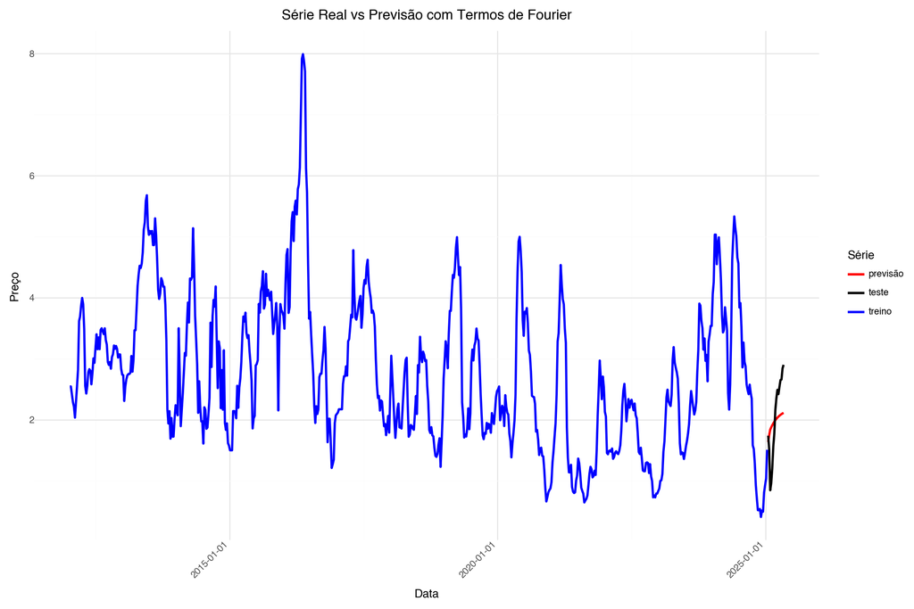

```python
# Criar um DataFrame com os resultados
df_plot = pd.DataFrame({
    'date': index,                      # índice completo
    'real': y,                          # série original completa
    'tipo': ['treino'] * len(y)        # inicializa como treino
})

# Atualiza os últimos 16 valores como teste
df_plot.loc[len(y) - 16:, 'tipo'] = 'teste'

# Adiciona a previsão
df_forecast = pd.DataFrame({
    'date': index[-16:],
    'real': forecast,
    'tipo': ['previsão'] * 16
})

# Junta tudo
df_final = pd.concat([df_plot, df_forecast], ignore_index=True)

# Gráfico com plotnine
grafico = (
    p9.ggplot(df_final, p9.aes(x='date', y='real', color='tipo')) +
    p9.geom_line(size=1.2) +
    p9.scale_color_manual(values={'treino': 'blue', 'teste': 'black', 'previsão': 'red'}) +
    p9.labs(title='Série Real vs Previsão com Termos de Fourier',
         x='Data', y='Preço', color='Série') +
    p9.theme_minimal() +
    p9.theme(axis_text_x=p9.element_text(rotation=45, hjust=1))+
    p9.theme(
        figure_size=(12, 8)
        )
)

print(grafico)
```